# Homework 2

Andrew Wong, Heather Shapiro, Jessie Li, Dipesh Gautam

### Introduction

According to the late comedian, Mitch Hedberg, “La Quinta is Spanish for next to Dennyâ€™s”. In order to assess this claim, John Reiser scraped the location data for all US locations of La Quinta hotels and Denny’s restaurants and analyzed the scraped data.

### Scraping the data

We separated the data mining into sections of downloading and parsing for both the La Quinta and Denny’s datasets.

### La Quinta Data Download

In order to get the La Quinta data, we searched the website to find the page with the most information. We found that the most data could be found using the interactive map on their “Find a Hotel” page (http://www.lq.com/en/findandbook.html). After noticing that parts of the html page contain chunks of XML code, we downloaded the content from this url, and separated these chunks out for each individual hotel. By searching for the regular expression starting with “hotelList.push”, we were able to break the content up for each hotel. After converting the XML chunks into dataframes, we were able to find the Title, InnNumber, Latitude, Longitude, ImagePath, isInnAndSuites, street, street2, city, stateProv, postalCode, and countryDisplay for every La Quinta hotel in the United States, Mexico, and Canada.

We took our parsing one step further in order to get the phone and fax numbers for each individual hotel. All of the hotels have their own inn number, which we could then use to go to each specific hotel webpage. We scraped each of these individual webpages, and then split each page to find both of these numbers. Surprisingly, many of the hotels listed on La Quinta’s site do not have their own sites, despite having links to them, and instead direct you back to the La Quinta Inn & Suites Chicago Downtown location. Thus, many of the points have the same phone and fax numbers.

### Denny’s Data Download

We downloaded Denny’s data using the same method described in John Reiser’s blog. In the blog, he downloads the data for the continental US by using Washington, DC and Salt Lake City, UT as centers of two search radius. To obtain complete list of Denny’s restaurants we added three more locations, Fairbanks, AK, Kahului, HI and Thompson, MB. We were able to get locations in Alaska, Hawaii and all of Canada using these locations. We parsed the required information on all Denny’s location including latitude and longitude, address and phone number from the downloaded XML files. We then removed Denny’s locations in Dominican Republic and Puerto Rico as there are no La Quintas in those locations.

### Distance Analysis

After scraping Denny’s and La Quinta’s respective websites then parsing the downloaded data, we used the `rdist.earth` function from the `fields` package to calculate the “great-circle” distance rather than Euclidean distance between each element of the La Quinta and Denny’s sets. Such a calculation accounts for the ellipsoidal shape of the earth. There are nuances `rdist.earth` that informed the parameters chosen for it. A close examination of the `rdist.earth` source code reveals the assumption that the equitorial radius of the earth is 6378 km, which Wikipedia states is actually the the maximum radius of Earth if it was a perfect sphere. A quick Google search shows that the mean radius for earth is actually 6371 km so it is what we use for our calculations. Additionally, while the World Geodetic System (WGS) put forth standard EPSG:4326, stating latitude should be put before longitude when referenced, the `rdist.earth` function requires inputs in the reverse order. Incorrect ordering of input gives different results. Having explained the package used for our distance analysis, we proceed to describe the code used for the calculation.

We used `rdist.earth` within two `for` loops. Since La Quinta is only in North America, it is in a subset of the total geographic expanse of Denny’s, which is international. Therefore, we should use La Quinta’s as our point of reference and be put in the first `for` loop. This guarantees that every La Quinta will be matched to a Denny’s, rather than the converse. Denny’s in the United Arab Emirates and New Zealand, for example, will be left matchless. The second `for` loop cycles through each of the Denny’s and stores the distance between it with the selected La Quinta in a vector, `distances.all`. After all Denny’s have been checked, the minimum distance in the `distances.all` is returned and stored in `distances.min`. Also, the index number for the Denny’s is stored in a matrix, `index`, so we can reference the points that give this distance. La Quinta is given by the row number of `index`, since it runs sequentially from 1 to 875. `distances.all` is reset to `NULL` and the process repeats with the next La Quinta.

A data frame, `all.df`, is created to store the indices of the La Quintas and Denny’s and the distance data in terms of kilometers and miles. The longitudes and latitudes of each of the matched La Quintas and Denny’s are also stored in `all.df` by a different `for` loop. We used a new `for` loop to do this with the idea of modular programming in mind, which allows easier debugging during the programming process. The data is then saved as the `analysis.Rdata` file, and graphically analyzed below.

### Data Analysis

```
## [1] "within 100m:" "30"           "Within 150m:" "49"
```

### Create a histogram

The histogram below shows the total number of Denny’s-La Quinta permutations within certain distances of each other. We excluded pairings with distances greater than 25 miles.

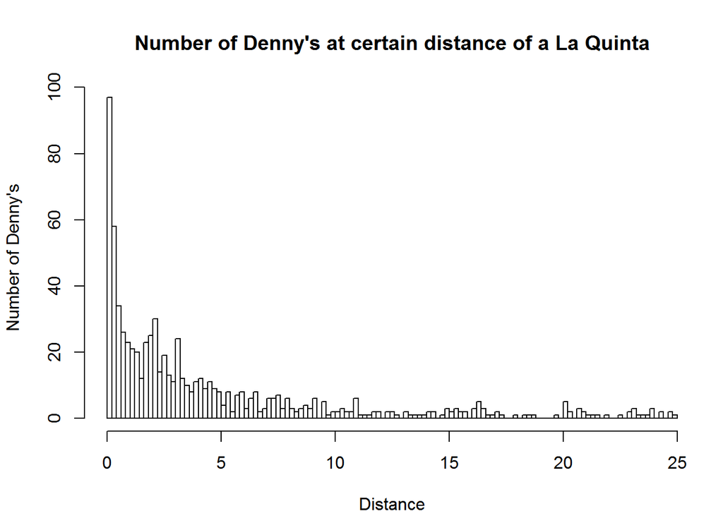

### Distances

Here we look at the cumulative percentage of combinations within certain distance. We see that 90% of the time there will be a Denny’s within 40 miles of a La Quinta.

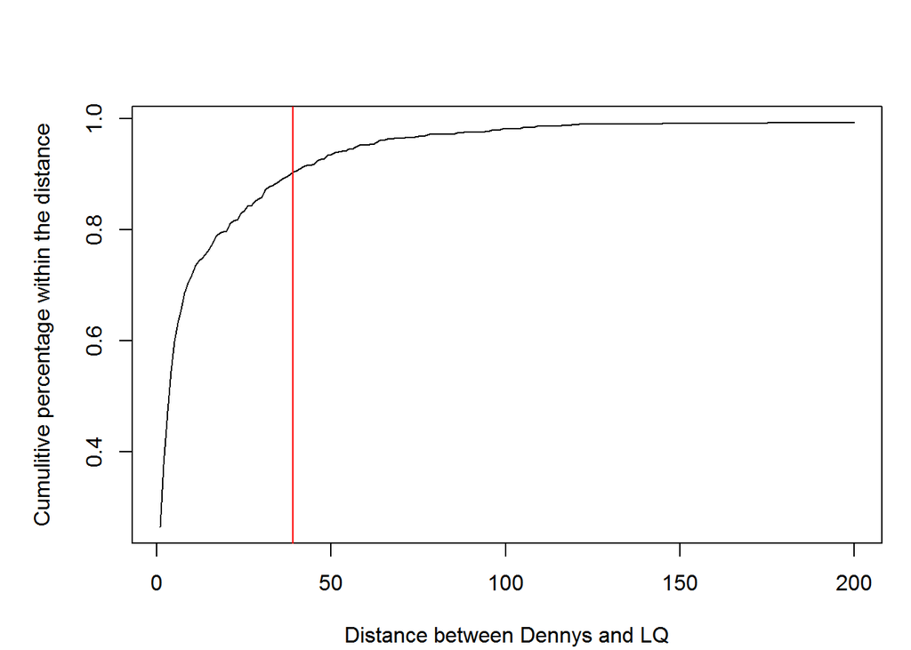

```
## [1] 39
```

### Map

The below map shows an application of our distance metrics. For any given La Quinta hotel, we found the closest Denny’s location. The map displays the Denny’s that is closest to the most La Quinta hotels, and shows the connections between the restaurant and each hotel. Currently, the Denny’s that was matched to the most La Quinta hotels is located in Metairie, Louisiana, with 19 hotel connections.

[figure not shown]